# demo_ggraph_visNetwork_intergraph

Wenwen Cao, Qiling Wu, Ruiheng Sun

# ggraph

**ggraph** is a R package for network visualization, using ggplot2 syntax. The ggplot2 package and its extensions are known for offering the most meaningfully structured and advanced way to visualize data in R. In ggplot2, you can select from a variety of visual building blocks and add them to your graphics one by one, a layer at a time.

The ggraph package takes this principle and extends it to network data. In this section, we’ll cover the basics of graphics approach. For a deeper look, it would be best to get familiar with ggplot2 first, then learn the specifics of ggraph.

## Import data

```r
nodes <- read.csv("Dataset1-Media-Example-NODES.csv", header=T, as.is=T)
links <- read.csv("Dataset1-Media-Example-EDGES.csv", header=T, as.is=T)

#install.packages("igraph")
library('igraph')
```

## Package you need for ggraph

```r
# install.packages("ggraph")

library(ggraph)
```

## Create New Object

- `graph_from_data_frame()`: create a network object from nodes and edges
- `edges`: defines connections between nodes
- `vertices = nodes`: provides node attributes (e.g., name, major)
- `directed = TRUE`: indicates the network is directed

```r
net <- graph_from_data_frame(links, vertices = nodes, directed = TRUE)
```

## Basic Visualization

- `ggraph(net)`: initialize the plot with the network object
- `geom_edge_link()`: draw edges (connections between nodes)
- `geom_node_point()`: draw nodes (vertices)

```
## Using "stress" as default layout
```

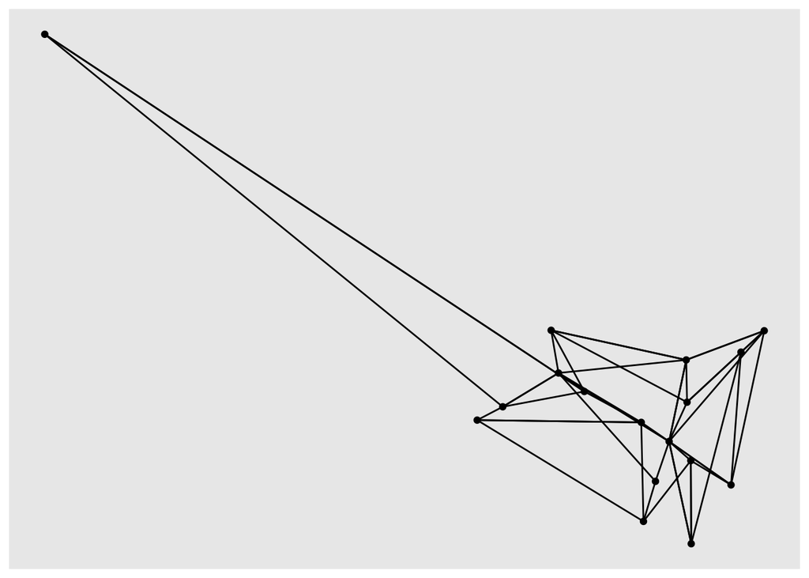

```r
library(ggraph)

ggraph(net) +
  geom_edge_link() +   # edges
  geom_node_point()    # nodes
```

## Layout

- `layout = "fr"`: force-directed layout (Fruchterman-Reingold). Other options include:‘star’, ‘circle’, ‘grid’, ‘sphere’, ‘kk’, ‘fr’, ‘mds’, ‘gem’, etc.

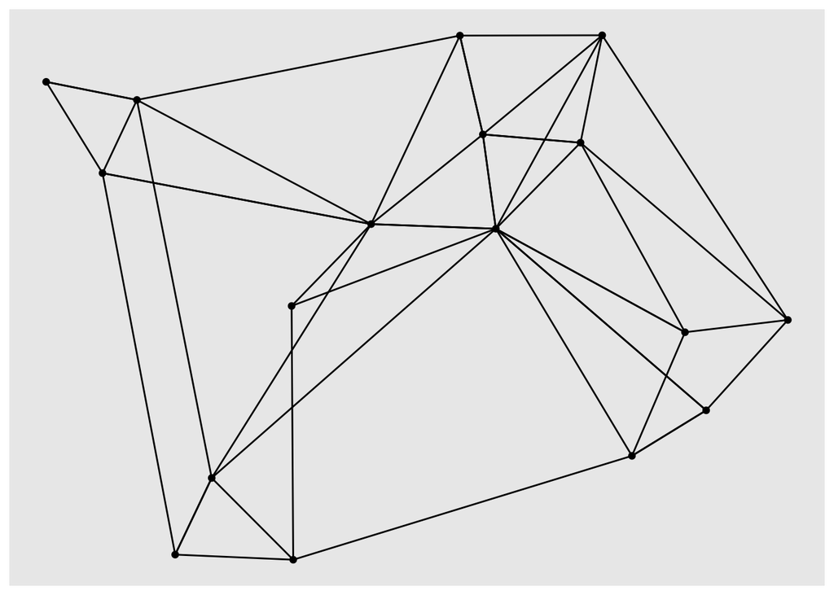

```r
ggraph(net, layout = "fr") +
  geom_edge_link() +
  geom_node_point()
```

- `"circle"`: place nodes in a circular layout

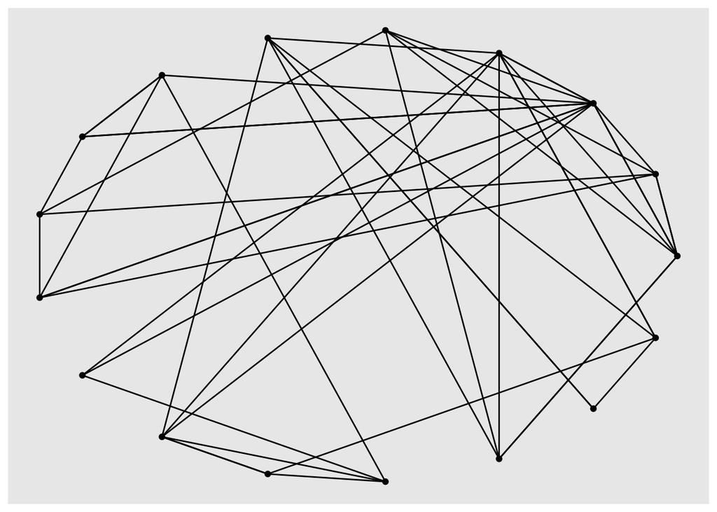

```r
ggraph(net, layout = "circle") +
  geom_edge_link() +
  geom_node_point()
```

## Edge styles

- `geom_edge_fan()`: draw curved edges (useful for overlapping edges)
- `color`: edge color
- `width`: edge thickness
- `alpha`: transparency (0–1)
- `theme_void()`: remove background and axes Here we can use `geom_edge_link()` for straight edges, `geom_edge_arc()` for curved ones, and `geom_edge_fan()` when we want to make sure any overlapping multiplex edges will be fanned out.

As in other packages, we can set visual properties for the network plot by using key function parameters. For instance, nodes have `color`, `fill`, `shape`, `size`, and `stroke`. Edges have `color`, `width`, and `linetype`. Here too the alpha parameter controls transparency.

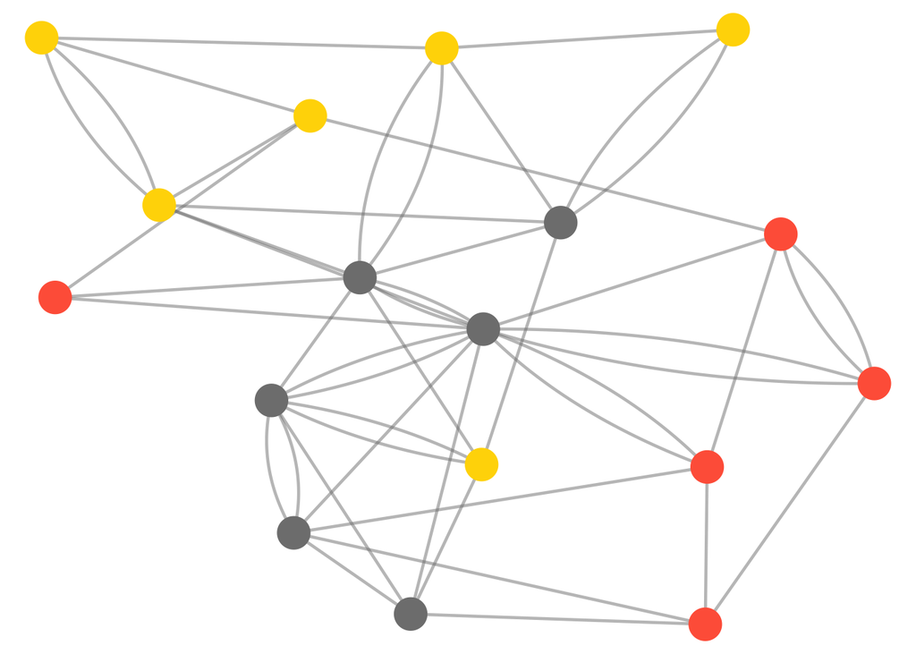

```r
# set node colors based on media type
colrs <- c("gray50", "tomato", "gold")
V(net)$color <- colrs[V(net)$media.type]

ggraph(net, layout="gem") +
  geom_edge_fan(color="gray50", width=0.8, alpha=0.5) +
  geom_node_point(color=V(net)$color, size=8) +
  theme_void()
```

- `linear`: arrange nodes in a straight line As in ggplot2, we can add different themes to the plot. For a cleaner look, you can use a minimal or empty theme with theme_minimal() or theme_void().

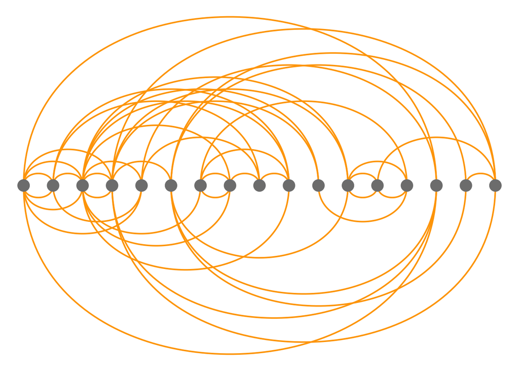

```r
ggraph(net, layout = 'linear') +
    geom_edge_arc(color = "orange", width=0.7) +
    geom_node_point(size=5, color="gray50") +
    theme_void()
```

## Node Aesthetics

- `aes()`: map data variables to visual properties
- `color = audience.size`: color nodes based on attribute `audience.size`
- `size`: node size The ggraph package also uses the traditional`ggplot2` way of mapping aesthetics: that is to say, of specifying which elements of the data should correspond to different visual properties of the graphic. This is done using the `aes()` function that matches visual parameters with attribute names from the data. In the code below, the edge attribute `type` and node attribute `audience.size` are taken from our data as they are included in the `igraph` object.

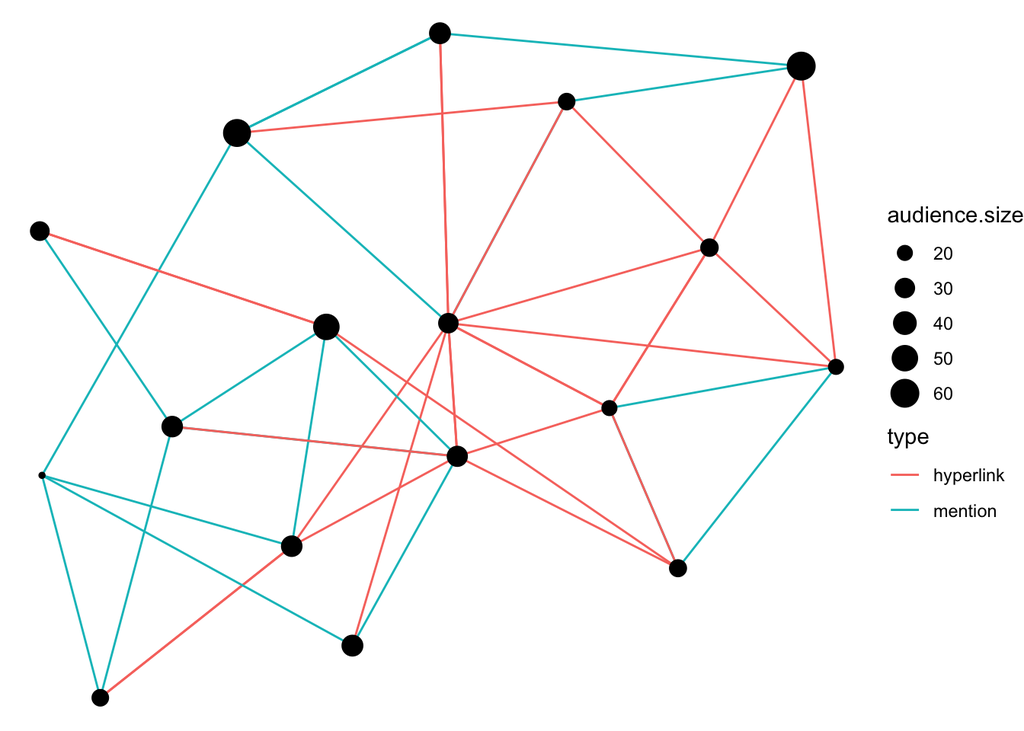

```r
ggraph(net, layout="gem") +
  geom_edge_link(aes(color = type)) +           # colors by edge type
  geom_node_point(aes(size = audience.size)) +  # size by audience size
  theme_void()
```

## Add Labels

One great thing about `ggplot2` and ggraph you can see above is that they automatically generate a legend which makes plots easier to interpret.

We can add a layer with node labels using `geom_node_text()` or `geom_node_label()` which correspond to similar functions in `ggplot2`.

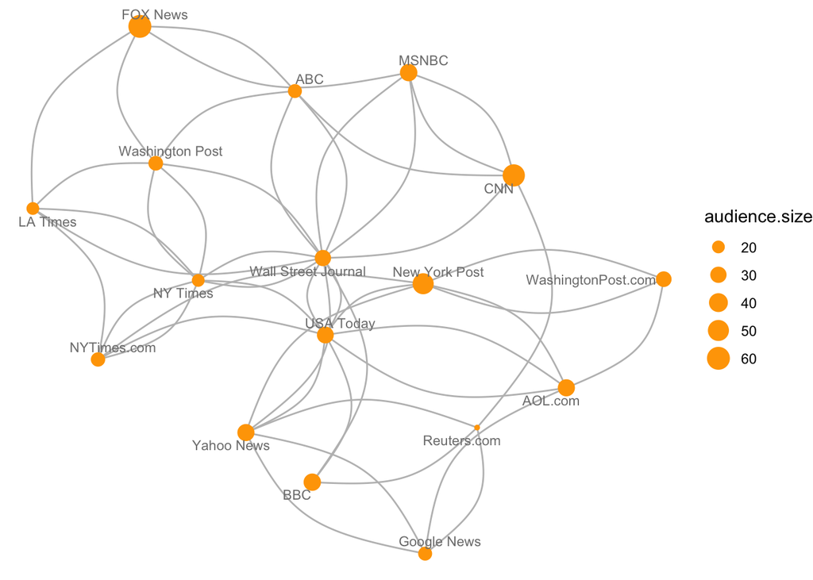

```r
ggraph(net,  layout = 'gem') +
  geom_edge_arc(color="gray", strength=0.3) +
  geom_node_point(color="orange", aes(size = audience.size)) +
  geom_node_text(aes(label = media), size=3, color="gray50", repel=T) +
  theme_void()
```

# visNetwork

**visNetwork** is a R package for network visualization, using vis.js javascript library (https://visjs.org).

Package you need for visNetwork

```r
# install.packages("visNetwork")
library(visNetwork)
```

visNetwork needs at least two informations :

- a nodes data.frame, with id column
- a edges data.frame, with from and to columns

### Nodes

- A nodes data.frame must have an `id` column
- Other optional columns can also be added into our nodes data.frame

```r
nodes <- data.frame(id=1:7, # id column (must be called id)
                    name=c("Asher","Bella","Chloe","Daniel","Emma","Frank","Gabriel"), # student names
                    major=c("CS","CS","CS","STAT","DS","DS","DS"), # CS: computer science major, STAT: statistics major, DS: data science major
                    major.type=c(1,1,1,2,3,3,3)) # 1: CS, 2: STAT, 3: DS
data.frame(nodes)
```

```
##   id    name major major.type
## 1  1   Asher    CS          1
## 2  2   Bella    CS          1
## 3  3   Chloe    CS          1
## 4  4  Daniel  STAT          2
## 5  5    Emma    DS          3
## 6  6   Frank    DS          3
## 7  7 Gabriel    DS          3
```

### Edges

- An edges data.frame must include a `from` column and a `to` column
- We also add a `weight` column on our edges data.frame to describe the frequency of interactions between two nodes.
- For example, in the first row, we know student 1 reached out to student 2 once.

```r
edges <- data.frame(from=c(1,1,2,3,5,5,6,7),
                    to=c(2,4,3,1,4,6,7,5),
                    weight=c(1,1,1,1,1,1,1,1))
data.frame(edges)
```

```
##   from to weight
## 1    1  2      1
## 2    1  4      1
## 3    2  3      1
## 4    3  1      1
## 5    5  4      1
## 6    5  6      1
## 7    6  7      1
## 8    7  5      1
```

### Visualiztion

```r
visNetwork(nodes, edges)
```

[interactive chart not shown]

### Customize Node

```r
# install.packages("RColorBrewer")
# install.packages("dplyr")
library(RColorBrewer)
library(dplyr)
# use three colors to distinguish students by their majors
colors <- colorRampPalette(brewer.pal(3, "RdBu"))(3)

nodes <- nodes %>%
  mutate(shape="dot", # "shape" variable: customize shape of nodes ("dot", "square", "triangle")
         shadow=TRUE, # "shadow" variable: include/exclude shadow of nodes
         title=major, # "title" variable: tooltip (html or character), when the mouse is above
         label=name, # "label" variable: add labels on nodes
         size=20, # "size" variable: set size of nodes
         borderWidth=1, # "borderWidth" variable: set border width of nodes
         color.background=colors[major.type], # "color.background" variable: set color of nodes
         color.border="grey", # "color.border" variable: set frame color
         color.highlight.background="yellow", # "color.highlight.background" variable: set color of the selected node
         color.highlight.border="black") # "color.highlight.border" variable: set frame color of the selected node

visNetwork(nodes, edges, width="100%", main="Student Interaction Network") %>% # "main" variable: add a title
  visLayout(randomSeed=4) # give a random seed manually so that the layout will be the same every time
```

[interactive chart not shown]

### Customize Edge

```r
edges <- edges %>% mutate(width=weight*3, # "width" variable: set width of each edge
                          color="lightgrey", # "color" variable: set color of edges
                          arrows="to", # "arrows" variable: set arrow for each edge ("to", "middle", "from ")
                          smooth=TRUE) # "smooth" variable: each edge to be curved or not

visNetwork(nodes, edges, width="100%", main="Student Interaction Network") %>%
  visLayout(randomSeed=4)
```

[interactive chart not shown]

### Add Legend Based on Groups

```r
nodes <- nodes %>% mutate(group=major) # add a "group" column on node data.frame and add groups on nodes
visNetwork(nodes, edges, width="100%", main="Student Interaction Network") %>%
  visLayout(randomSeed=4) %>%
  visGroups(groupname="CS", color=colors[1]) %>% # color "colors[1]" for "CS" group
  visGroups(groupname="STAT", color=colors[2]) %>%
  visGroups(groupname="DS", color=colors[3]) %>%
  visLegend(width=0.1, position="right", main="Academic Major") # "position" variable: set position ("left", "right")
```

[interactive chart not shown]

### Select by Node

```r
nodes <- nodes %>% select(-group) # remove "group" column because we don't want to show legend this time
visNetwork(nodes, edges, width="100%", main="Student Interaction Network") %>%
  visLayout(randomSeed=4) %>%
  visOptions(nodesIdSelection=TRUE, # "nodesIdSelection" variable: select a node by id
             selectedBy="major") %>% # "selectedBy" variable: select a node by the values of a column such as "major" column
  visLegend()
```

[interactive chart not shown]

### Highlight Nearest Nodes

```r
visNetwork(nodes, edges, width="100%", main="Student Interaction Network") %>%
  visLayout(randomSeed=4) %>%
  visOptions(highlightNearest = list(enabled = TRUE, # "enabled" variable: highlight nearest nodes and edges by clicking on a node
  degree = 2)) # "degree" variable: set degree of depth
```

[interactive chart not shown]

### Edit Network

```r
visNetwork(nodes, edges, width="100%", main="Student Interaction Network") %>%
  visLayout(randomSeed=4) %>%
  visOptions(highlightNearest=TRUE, # degree of depth = 1
             nodesIdSelection=TRUE,
             selectedBy="major",
             manipulation=TRUE) %>%  # "manipulation" variable: add/delete nodes/edges or change edges
  visLegend()
```

[interactive chart not shown]

### Add Navigation Buttons and Control Interactions

```r
our_network <- visNetwork(nodes, edges, width="100%", main="Student Interaction Network") %>%
  visLayout(randomSeed=4) %>%
  visOptions(highlightNearest=TRUE,
             nodesIdSelection=TRUE,
             selectedBy="major") %>%
  visInteraction(hideEdgesOnDrag=TRUE, # "hideEdgesOnDrag" variable: hide edges when dragging the view
  dragNodes=TRUE, # "dragNodes" variable: hide nodes when dragging the view
  dragView=TRUE, # "dragView" variable: enable or not the movement of the full network
  zoomView=TRUE, # "zoomView" variable: enable or not the zoom (use mouse scroll)
  navigationButtons=TRUE) %>% # "navigationButtons" variable: show navigation buttons
  visLegend()
```

### Export

we use `visSave()` to save network in html file.

```r
visSave(our_network, file = "Student Interaction Network.html", background="white")
```

# intergraph and igraph

**intergraph** is an R package used to convert network objects between `network` and `igraph`.

**igraph** is a R package for network analysis and visualization.

Packages you need for intergraph and igraph

```r
# install.packages("intergraph")
# install.packages("igraph")
# install.packages("network")

library(intergraph)
library(igraph)
library(network)
```

**intergraph** mainly works with two types of network objects: a network object an igraph object

## Two common conversion functions are:

asIgraph() : convert a network object to an igraph object

asNetwork() : convert an igraph object to a network object

### Network conversion: igraph and network

**intergraph** is used to convert between `igraph` and `network` objects.

```r
library(intergraph)
library(igraph)
library(network)

# Create a sumple edge list
edges <- data.frame(
  from = c("A", "A", "B", "C"),
  to   = c("B", "C", "D", "D")
)

edges
```

```
##   from to
## 1    A  B
## 2    A  C
## 3    B  D
## 4    C  D
```

Create an igraph object from the edge list

```r
g <- graph_from_data_frame(edges, directed = FALSE)

g
```

```
## IGRAPH 34b9b95 UN-- 4 4 --
## + attr: name (v/c)
## + edges from 34b9b95 (vertex names):
## [1] A--B A--C B--D C--D
```

```r
summary(g)
```

```
## IGRAPH 34b9b95 UN-- 4 4 --
## + attr: name (v/c)
```

Convert igraph to network

```r
net <- asNetwork(g)

net
```

```
##  Network attributes:
##   vertices = 4
##   directed = FALSE
##   hyper = FALSE
##   loops = FALSE
##   multiple = FALSE
##   bipartite = FALSE
##   total edges= 4
##     missing edges= 0
##     non-missing edges= 4
##
##  Vertex attribute names:
##     vertex.names
##
## No edge attributes
```

```r
summary(net)
```

```
## Network attributes:
##   vertices = 4
##   directed = FALSE
##   hyper = FALSE
##   loops = FALSE
##   multiple = FALSE
##   bipartite = FALSE
##  total edges = 4
##    missing edges = 0
##    non-missing edges = 4
##  density = 0.6666667
##
## Vertex attributes:
##   vertex.names:
##    character valued attribute
##    4 valid vertex names
##
## No edge attributes
##
## Network adjacency matrix:
##   A B C D
## A 0 1 1 0
## B 1 0 0 1
## C 1 0 0 1
## D 0 1 1 0
```

Check the edge list of the network object

```r
as.matrix(net, "edgelist")
```

```
##      [,1] [,2]
## [1,]    1    2
## [2,]    1    3
## [3,]    2    4
## [4,]    3    4
## attr(,"n")
## [1] 4
## attr(,"vnames")
## [1] "A" "B" "C" "D"
```

Convert network back to igraph

```r
g2 <- asIgraph(net)

g2
```

```
## IGRAPH a715086 U--- 4 4 --
## + attr: na (v/l), vertex.names (v/c), na (e/l)
## + edges from a715086:
## [1] 1--2 1--3 2--4 3--4
```

```r
summary(g2)
```

```
## IGRAPH a715086 U--- 4 4 --
## + attr: na (v/l), vertex.names (v/c), na (e/l)
```

Check the edge list of the converted igraph object

```r
igraph::as_edgelist(g2)
```

```
##      [,1] [,2]
## [1,]    1    2
## [2,]    1    3
## [3,]    2    4
## [4,]    3    4
```

Compare whether the two objects represent the same network

```r
all.equal(
  igraph::as_edgelist(g),
  structure(as.matrix(net, "edgelist"), ncol = 2)
)
```

```
## [1] "Modes: character, numeric"
## [2] "Attributes: < Length mismatch: comparison on first 1 components >"
## [3] "8 string mismatches"
```

Compare them more formally

```r
netcompare(g, net)
```

```
##
## Identical adjacency matrices:
##     TRUE
##
## Network-level features:
##          target current
## vcount   4      4
## ecount   4      4
## directed FALSE  FALSE
##
## Presence of network-level attributes
##           target current
## n         0      7
## bipartite FALSE   TRUE
## directed  FALSE   TRUE
## hyper     FALSE   TRUE
## loops     FALSE   TRUE
## mnext     FALSE   TRUE
## multiple  FALSE   TRUE
## n         FALSE   TRUE
## Common attributes comparison (TRUE=identical)
##    No common attributes
##
## Presence of vertex-level attributes
##              target current
## n            1      2
## name          TRUE  FALSE
## na           FALSE   TRUE
## vertex.names FALSE   TRUE
## Common attributes comparison (TRUE=identical)
##    No common attributes
##
## Presence of edge-level attributes
##    target current
## n  0      1
## na FALSE   TRUE
## Common attributes comparison (TRUE=identical)
##    No common attributes
```

Here we compare the edge lists to check whether the connections between nodes are preserved after conversion. Although all.equal() shows some mismatches due to different data types and attribute formats, the adjacency matrices are identical, which means the network structure is preserved.